# Assignment5Report

Louis Fabrice Tshimanga

12 giugno 2019

# Problem Description

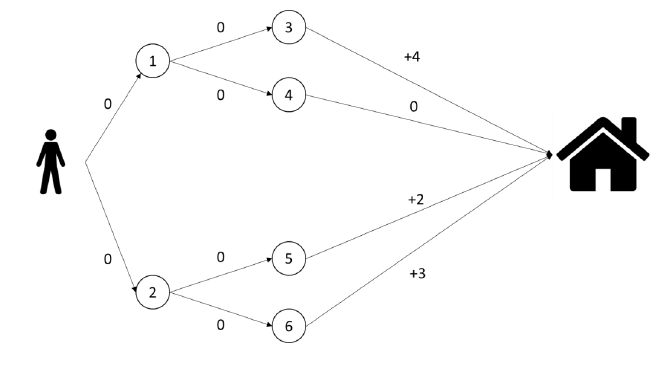

“**Figure 1**: representation of the problem”

From the Assignment 5, the paths graph is a directed “tree” from starting point S to points 1, 2; from point 1 to points 3, 4, and from point 2 to points 5, 6. Points 3, 4, 5, 6 all lead to target point H.

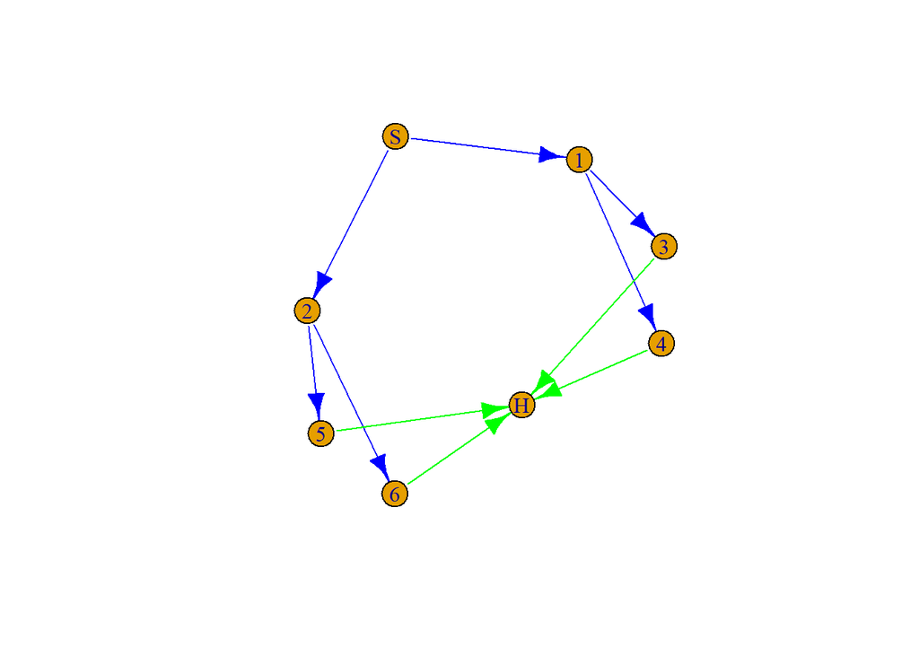

The rewards are all null except for edges $\{3, H\}$, $\{5, H\}$ and $\{6, H\}$:
$$R(3,H)=+4\\
R(5,H)=+2\\
R(6,H)=+3\\$$

### Graph Descriptive Matrix

We could describe the graph with a node-to-node matrix $G$ where the value of the element $g_{ij}$ is equal to the verse of the edge from $i$-th to $j$-th nodes (just a dispensable convention). Note that here, node S is the first node, node H is the eighth node, and the numbered one are shifted (the second row represents edges starting from node named 1, and so forth):
$$G=\left(\begin{array}{cc}
0&1&1&0&0&0&0&0\\
-1&0&0&1&1&0&0&0\\
-1&0&0&0&0&1&1&0\\
0&-1&0&0&0&0&0&1\\
0&-1&0&0&0&0&0&1\\
0&0&-1&0&0&0&0&1\\
0&0&-1&0&0&0&0&1\\
0&0&0&-1&-1&-1&-1&0\\
\end{array}\right)$$

### Transition dynamics Matrix

The case is deterministic in the sense that each action has its definite prescribed outcome, so the Transition Matrix would be a sparse matrix with the $1$’s of $t_{ij}$ in accordance with the given policy stating actions $a=i\to j$

### Policy-0

$\pi_0=\{0\to2,2\to5,1\to4\}$, with no need to specify actions for the set of state-nodes $\{3,4,5,6\}$ since they’re not actual *decision* nodes: each of them leads to point $H$, with a different reward.

# Solutions

1. **Compute the state function $V^{\pi_0}(s) \ \ \forall s \in S$**

Given $\pi_0=\{0\to2,2\to5,1\to4\}$
$$V^{\pi_0}(0)=R(0, a=0\to2)+R(2, a=2\to5)+R(5,a=5\to H)=0+0+2=2\\
V^{\pi_0}(1)=R(1, a=1\to4)+R(4, a=4\to H)=0+0=0\\
V^{\pi_0}(2)=R(2, a=2\to5)+R(5,a=5\to H)=0+2=2\\
V^{\pi_0}(3)\equiv4\\
V^{\pi_0}(4)\equiv0\\
V^{\pi_0}(5)\equiv2\\
V^{\pi_0}(6)\equiv3\\$$

2. **Improve the policy to obtain the new $\pi_1$**

An improvement could be obtained by a single action change with $\pi_1=\{0\to2, 2\to6,1\to4\}$, in which the alternative action executable in state $2$ is taken.

4. **Improve again the policy to obtain the new $\pi_2$**

An improvement could be obtained by a single action change with $\pi_2=\{0\to2,2\to6,1\to3\}$, in which the alternative action executable in state $1$ is taken.

It is quite evident that $\pi_2$ is not optimal, since state $1$ has a higher value than state $2$ and the policy doesn’t contain an action pointing towards $1$, namely $a^*=0\to1$ instead of $a^{\pi_{2}}=0\to2$. Given $\pi_3=\{0\to1,0\to3,2\to6\}$, any “improvement” of the array $\{V^{\pi}(s) \ \ \forall s \in S\}$ would lead again to $\pi_3$, implying a convergence thus the optimality of the latest policy.